# R Aula 05

# Probabilidade

## Analise de variancia

É um rocedimento usado para comparar a distribuição de três ou mais grupos em amostras independentes.

Só pode ser feita com mais de 2 grupos.

Você trabalha para invaldar a hipótese nula (H0)

## Anova

Carregar os dados

```r
tratamento <-  read.csv('anova.csv', sep = ';')
tratamento
```

| Sexo | Remedio | Horas |
| --- | --- | --- |
| F | A | 5 |
| F | A | 10 |
| F | A | 7 |
| F | A | 7 |
| M | A | 7 |
| M | A | 6 |
| M | A | 9 |
| M | A | 9 |
| F | B | 5 |
| F | B | 5 |

[output cut: 14 more lines]

```r
dim(tratamento)
```

```
## [1] 24  3
```

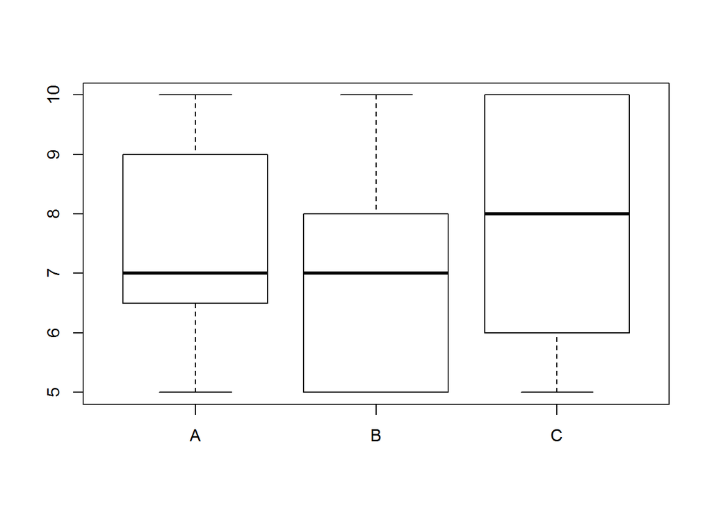

```r
boxplot(Horas ~ Remedio, data = tratamento)
```

Criando a anova

```r
an <- aov(Horas ~ Remedio, data = tratamento)
an
```

```
## Call:
##    aov(formula = Horas ~ Remedio, data = tratamento)
##
## Terms:
##                  Remedio Residuals
## Sum of Squares   4.08333  79.75000
## Deg. of Freedom        2        21
##
## Residual standard error: 1.948748
## Estimated effects may be unbalanced
```

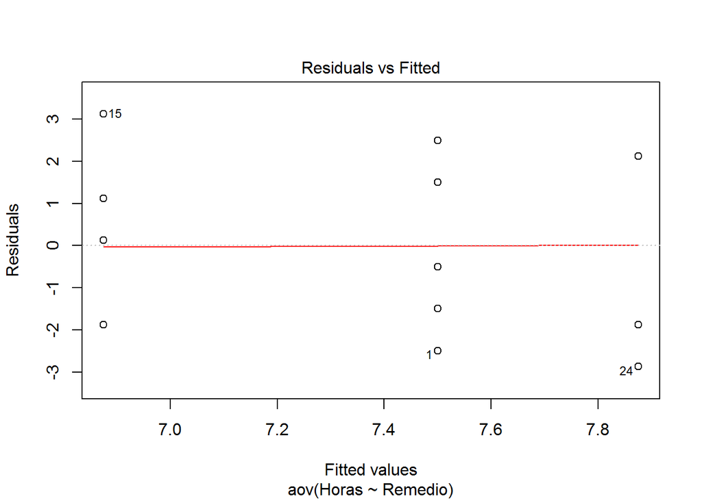

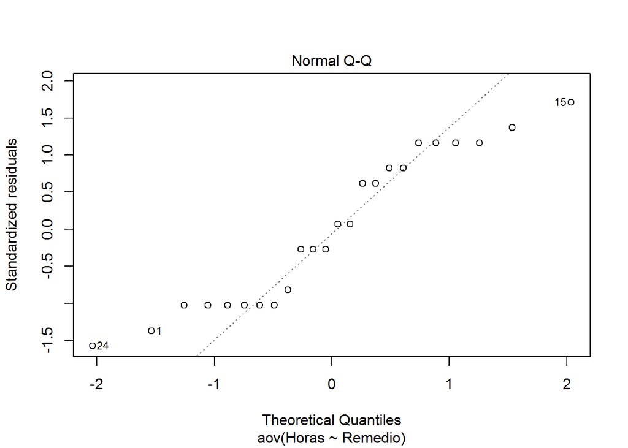

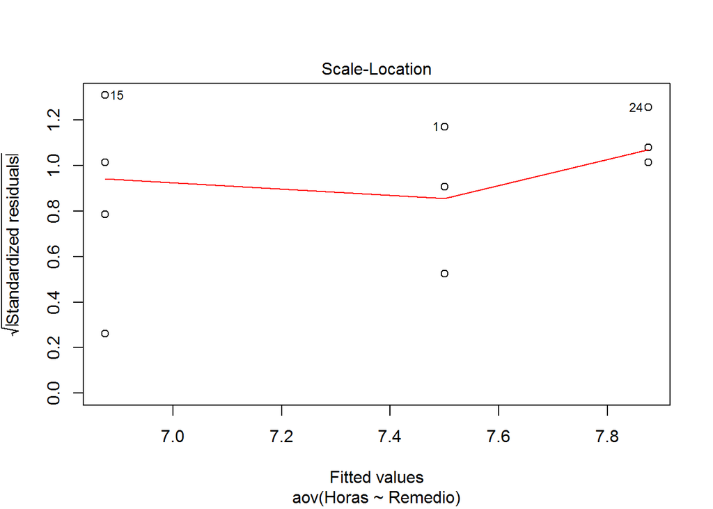

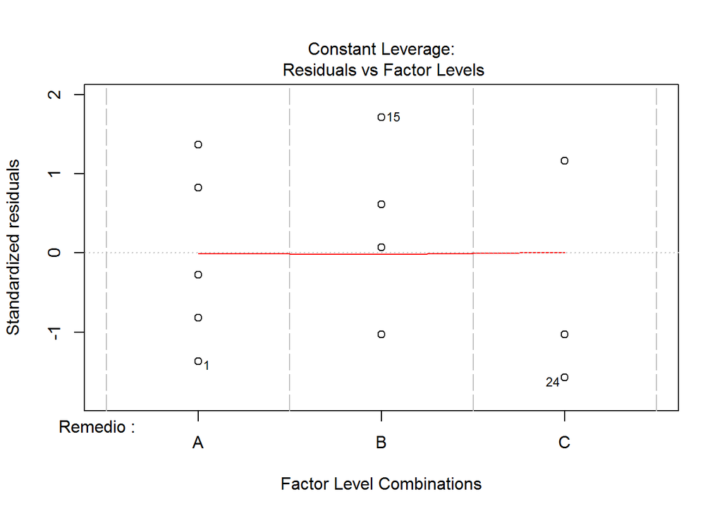

```r
plot(an)
```

```r
summary(an)
```

```
##             Df Sum Sq Mean Sq F value Pr(>F)
## Remedio      2   4.08   2.042   0.538  0.592
## Residuals   21  79.75   3.798
```

O pr(>F) é o Pvalue, que se for 0.05 é uma hipótese nula

```r
an <- aov(Horas ~ Remedio * Sexo, data = tratamento)
an
```

```
## Call:
##    aov(formula = Horas ~ Remedio * Sexo, data = tratamento)
##
## Terms:
##                  Remedio     Sexo Remedio:Sexo Residuals
## Sum of Squares   4.08333  4.16667      6.58333  69.00000
## Deg. of Freedom        2        1            2        18
##
## Residual standard error: 1.95789
## Estimated effects may be unbalanced
```

```r
summary(an)
```

```
##              Df Sum Sq Mean Sq F value Pr(>F)
## Remedio       2   4.08   2.042   0.533  0.596
## Sexo          1   4.17   4.167   1.087  0.311
## Remedio:Sexo  2   6.58   3.292   0.859  0.440
## Residuals    18  69.00   3.833
```

## Teste de tukey

Retorna a diferença entre os grupos

```r
an <- aov(Horas ~ Remedio, data = tratamento)
tukey <- TukeyHSD(an)
tukey
```

```
##   Tukey multiple comparisons of means
##     95% family-wise confidence level
##
## Fit: aov(formula = Horas ~ Remedio, data = tratamento)
##
## $Remedio
##       diff       lwr      upr     p adj
## B-A -0.625 -3.080978 1.830978 0.7991405
## C-A  0.375 -2.080978 2.830978 0.9218996
## C-B  1.000 -1.455978 3.455978 0.5689472
```

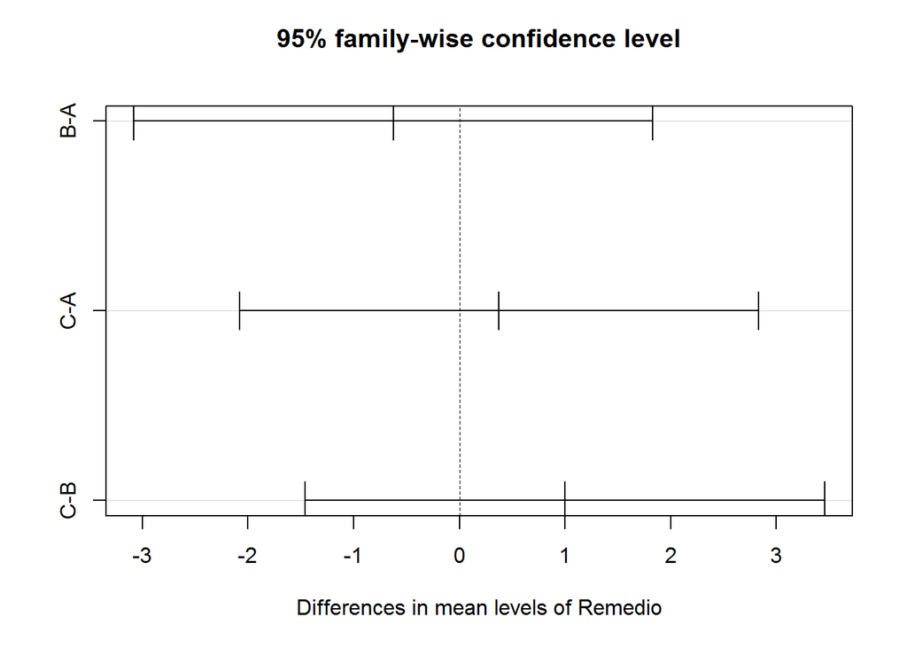

```r
plot(tukey)
```

# ML

## Árvore de decisão

```r
library('rpart')
```

```r
credito <- read.csv2('Credit.csv', sep = ',', header = T)
credito
```

| checking_status | duration | credit_history | purpose | credit_amount | savings_status | employment | installment_commitment | personal_status | other_parties | residence_since | property_magnitude | age | other_payment_plans | housing | existing_credits | job | num_dependents | own_telephone | foreign_worker | class |
| --- | --- | --- | --- | --- | --- | --- | --- | --- | --- | --- | --- | --- | --- | --- | --- | --- | --- | --- | --- | --- |
| <0 | 6 | 'critical/other existing credit' | radio/tv | 1169 | 'no known savings' | >=7 | 4 | 'male single' | none | 4 | 'real estate' | 67 | none | own | 2 | skilled | 1 | yes | yes | good |
| 0<=X<200 | 48 | 'existing paid' | radio/tv | 5951 | <100 | 1<=X<4 | 2 | 'female div/dep/mar' | none | 2 | 'real estate' | 22 | none | own | 1 | skilled | 1 | none | yes | bad |
| 'no checking' | 12 | 'critical/other existing credit' | education | 2096 | <100 | 4<=X<7 | 2 | 'male single' | none | 3 | 'real estate' | 49 | none | own | 1 | 'unskilled resident' | 2 | none | yes | good |
| <0 | 42 | 'existing paid' | furniture/equipment | 7882 | <100 | 4<=X<7 | 2 | 'male single' | guarantor | 4 | 'life insurance' | 45 | none | 'for free' | 1 | skilled | 2 | none | yes | good |
| <0 | 24 | 'delayed previously' | 'new car' | 4870 | <100 | 1<=X<4 | 3 | 'male single' | none | 4 | 'no known property' | 53 | none | 'for free' | 2 | skilled | 2 | none | yes | bad |
| 'no checking' | 36 | 'existing paid' | education | 9055 | 'no known savings' | 1<=X<4 | 2 | 'male single' | none | 4 | 'no known property' | 35 | none | 'for free' | 1 | 'unskilled resident' | 2 | yes | yes | good |
| 'no checking' | 24 | 'existing paid' | furniture/equipment | 2835 | 500<=X<1000 | >=7 | 3 | 'male single' | none | 4 | 'life insurance' | 53 | none | own | 1 | skilled | 1 | none | yes | good |
| 0<=X<200 | 36 | 'existing paid' | 'used car' | 6948 | <100 | 1<=X<4 | 2 | 'male single' | none | 2 | car | 35 | none | rent | 1 | 'high qualif/self emp/mgmt' | 1 | yes | yes | good |
| 'no checking' | 12 | 'existing paid' | radio/tv | 3059 | >=1000 | 4<=X<7 | 2 | 'male div/sep' | none | 4 | 'real estate' | 61 | none | own | 1 | 'unskilled resident' | 1 | none | yes | good |
| 0<=X<200 | 30 | 'critical/other existing credit' | 'new car' | 5234 | <100 | unemployed | 4 | 'male mar/wid' | none | 2 | car | 28 | none | own | 2 | 'high qualif/self emp/mgmt' | 1 | none | yes | bad |

[output cut: 990 more lines]

```r
amostra <- sample(2, 1000, replace = T, prob = c(0.7, 0.3))
amostra
```

```
##    [1] 1 2 1 1 2 1 1 1 1 1 1 1 1 1 1 1 1 1 2 2 1 1 1 2 2 2 2 1 2 2 1 1 1 2
##   [35] 2 1 1 1 1 1 1 1 1 1 1 1 2 1 1 1 1 2 1 1 1 1 1 2 2 1 1 1 2 1 2 2 1 1
##   [69] 2 1 2 1 1 2 2 2 1 1 1 1 1 1 1 1 2 1 1 1 1 1 2 1 2 1 1 1 1 1 2 1 1 1
##  [103] 2 1 2 1 1 2 1 1 2 1 1 2 2 1 1 2 2 2 1 1 1 1 1 1 2 1 1 1 1 1 1 1 1 1
##  [137] 1 1 1 1 2 1 2 1 1 2 1 1 1 1 1 1 1 2 2 1 1 1 1 1 2 1 1 1 1 1 2 2 1 2
##  [171] 1 2 1 1 1 1 1 2 1 2 1 2 1 1 1 1 1 2 2 1 2 2 2 1 2 1 2 1 1 1 1 2 1 2
##  [205] 1 2 1 1 2 2 1 1 1 1 1 2 2 1 1 2 2 1 1 1 2 1 1 2 1 1 1 1 1 2 2 2 1 1
##  [239] 1 2 1 1 1 2 1 2 1 1 1 1 2 1 1 1 1 1 2 2 2 1 2 1 2 1 1 1 1 1 1 1 2 1
##  [273] 2 1 1 2 1 1 1 2 1 1 2 2 2 1 2 1 2 1 2 1 1 1 1 1 2 1 2 1 2 2 2 1 1 1
##  [307] 1 1 1 2 2 2 1 1 1 1 1 1 1 2 1 1 1 1 1 2 1 1 2 1 1 1 2 1 2 2 1 1 2 1
##  [341] 1 2 1 1 1 1 1 2 1 2 1 1 1 2 2 1 1 1 1 1 1 1 1 2 1 1 1 2 1 1 1 2 1 1
##  [375] 2 1 1 1 1 2 1 2 1 2 1 1 1 1 1 1 2 1 2 1 1 1 1 2 1 2 1 1 1 2 1 1 1 2
##  [409] 1 1 1 2 1 1 2 2 2 1 1 1 1 1 1 1 1 2 2 1 1 2 2 1 1 1 2 2 1 1 2 2 1 1
##  [443] 1 1 2 1 2 2 1 1 2 2 2 1 2 1 2 1 1 1 2 1 1 1 2 1 2 1 1 1 1 1 2 2 1 1
##  [477] 1 1 1 2 1 2 1 2 1 1 1 1 1 1 1 1 1 1 2 2 2 1 1 2 1 1 2 1 1 1 2 2 1 2
##  [511] 2 1 2 2 2 1 1 2 2 1 2 2 1 1 1 1 1 2 1 1 2 2 1 1 1 1 2 1 2 1 1 1 1 1
##  [545] 2 1 1 2 1 1 1 1 1 2 2 1 2 1 2 1 1 2 1 1 2 1 1 1 2 1 2 1 2 1 1 2 1 2
##  [579] 2 1 1 1 1 1 1 1 2 1 2 2 2 1 2 1 1 1 1 2 1 2 1 2 2 1 1 1 1 1 2 1 2 2
##  [613] 2 1 2 1 1 1 1 1 2 1 2 2 1 2 2 2 1 1 2 1 1 1 1 2 1 1 1 1 1 1 1 1 1 1
##  [647] 1 2 1 1 2 1 1 1 1 1 1 1 1 1 2 1 1 1 2 1 1 1 1 1 1 1 1 1 2 1 1 1 1 2
##  [681] 1 1 1 1 2 2 2 1 1 1 2 2 2 1 1 1 2 1 1 2 1 1 1 1 1 1 1 1 1 2 1 2 2 1
##  [715] 1 1 1 2 2 1 1 1 2 2 1 1 1 2 1 1 1 1 1 1 1 1 1 2 1 1 1 1 1 2 1 1 2 1
##  [749] 1 1 1 2 1 1 2 1 1 2 1 1 2 2 1 1 2 2 2 1 2 2 2 1 1 1 1 2 2 2 2 1 2 2
##  [783] 1 1 1 2 1 1 2 1 1 1 1 2 2 2 2 2 1 1 2 1 1 2 1 2 1 2 1 1 1 2 1 1 1 1
##  [817] 1 2 2 1 2 1 1 1 1 2 1 1 1 1 2 1 1 2 2 1 2 1 2 1 1 1 1 1 2 1 1 1 1 2
##  [851] 1 1 1 1 1 1 1 1 1 1 1 1 1 1 1 1 2 1 2 1 2 1 1 1 2 1 2 1 1 2 1 1 1 2
##  [885] 2 1 1 1 1 2 1 1 1 2 1 1 1 2 1 1 1 1 1 2 1 2 1 1 1 1 1 1 1 1 1 1 2 1
##  [919] 2 1 2 1 1 1 2 2 1 1 2 1 2 1 2 1 2 2 1 1 1 1 1 1 2 1 1 1 1 1 1 1 2 2
##  [953] 2 1 2 1 2 1 1 1 1 1 1 2 1 1 1 1 2 2 1 2 1 1 2 1 1 1 1 1 1 1 1 1 2 1
##  [987] 1 1 1 1 1 2 2 1 1 1 1 2 2 1
```

Separando conjunto de teste e de treino

```r
creditotreino <- credito[amostra == 1,]
creditotest <- credito[amostra == 2,]

creditotest
```

|  | checking_status | duration | credit_history | purpose | credit_amount | savings_status | employment | installment_commitment | personal_status | other_parties | residence_since | property_magnitude | age | other_payment_plans | housing | existing_credits | job | num_dependents | own_telephone | foreign_worker | class |
| --- | --- | --- | --- | --- | --- | --- | --- | --- | --- | --- | --- | --- | --- | --- | --- | --- | --- | --- | --- | --- | --- |
| 2 | 0<=X<200 | 48 | 'existing paid' | radio/tv | 5951 | <100 | 1<=X<4 | 2 | 'female div/dep/mar' | none | 2 | 'real estate' | 22 | none | own | 1 | skilled | 1 | none | yes | bad |
| 5 | <0 | 24 | 'delayed previously' | 'new car' | 4870 | <100 | 1<=X<4 | 3 | 'male single' | none | 4 | 'no known property' | 53 | none | 'for free' | 2 | skilled | 2 | none | yes | bad |
| 19 | 0<=X<200 | 24 | 'existing paid' | 'used car' | 12579 | <100 | >=7 | 4 | 'female div/dep/mar' | none | 2 | 'no known property' | 44 | none | 'for free' | 1 | 'high qualif/self emp/mgmt' | 1 | yes | yes | bad |
| 20 | 'no checking' | 24 | 'existing paid' | radio/tv | 3430 | 500<=X<1000 | >=7 | 3 | 'male single' | none | 2 | car | 31 | none | own | 1 | skilled | 2 | yes | yes | good |
| 24 | 0<=X<200 | 12 | 'critical/other existing credit' | 'used car' | 1804 | 100<=X<500 | <1 | 3 | 'male single' | none | 4 | 'life insurance' | 44 | none | own | 1 | skilled | 1 | none | yes | good |
| 25 | 'no checking' | 10 | 'critical/other existing credit' | furniture/equipment | 2069 | 'no known savings' | 1<=X<4 | 2 | 'male mar/wid' | none | 1 | car | 26 | none | own | 2 | skilled | 1 | none | no | good |
| 26 | <0 | 6 | 'existing paid' | furniture/equipment | 1374 | <100 | 1<=X<4 | 1 | 'male single' | none | 2 | 'real estate' | 36 | bank | own | 1 | 'unskilled resident' | 1 | yes | yes | good |
| 27 | 'no checking' | 6 | 'no credits/all paid' | radio/tv | 426 | <100 | >=7 | 4 | 'male mar/wid' | none | 4 | car | 39 | none | own | 1 | 'unskilled resident' | 1 | none | yes | good |
| 29 | 0<=X<200 | 7 | 'existing paid' | radio/tv | 2415 | <100 | 1<=X<4 | 3 | 'male single' | guarantor | 2 | 'real estate' | 34 | none | own | 1 | skilled | 1 | none | yes | good |
| 30 | <0 | 60 | 'delayed previously' | business | 6836 | <100 | >=7 | 3 | 'male single' | none | 4 | 'no known property' | 63 | none | own | 2 | skilled | 1 | yes | yes | bad |

[output cut: 303 more lines]

```r
dim(creditotest)
```

```
## [1] 313  21
```

```r
dim(creditotreino)
```

```
## [1] 687  21
```

## Criação

Criação de modelo arvore decisão

class -> class -> metodo

Regressão -> anova -> metodo

Arvore -> modelo criado com algoritmo de arvore de decisão

```r
arvore <- rpart(class ~., data = creditotreino, method = "class")
arvore
```

```
## n= 687
##
## node), split, n, loss, yval, (yprob)
##       * denotes terminal node
##
##    1) root 687 210 good (0.30567686 0.69432314)
##      2) checking_status=<0,0<=X<200 366 166 good (0.45355191 0.54644809)
##        4) duration>=33 72  23 bad (0.68055556 0.31944444)
##          8) savings_status=<100,>=1000,100<=X<500 60  14 bad (0.76666667 0.23333333) *
##          9) savings_status='no known savings',500<=X<1000 12   3 good (0.25000000 0.75000000) *
##        5) duration< 33 294 117 good (0.39795918 0.60204082)
##         10) purpose='new car',education,other 100  43 bad (0.57000000 0.43000000)
##           20) property_magnitude='life insurance',car 59  18 bad (0.69491525 0.30508475)
##             40) employment=<1,>=7,unemployed 27   1 bad (0.96296296 0.03703704) *
##             41) employment=1<=X<4,4<=X<7 32  15 good (0.46875000 0.53125000)
##               82) credit_history='all paid','existing paid','no credits/all paid' 21   8 bad (0.61904762 0.38095238) *
##               83) credit_history='critical/other existing credit','delayed previously' 11   2 good (0.18181818 0.81818182) *
##           21) property_magnitude='no known property','real estate' 41  16 good (0.39024390 0.60975610)
##             42) duration>=14.5 18   7 bad (0.61111111 0.38888889) *
##             43) duration< 14.5 23   5 good (0.21739130 0.78260870) *
##         11) purpose='domestic appliance','used car',business,furniture/equipment,radio/tv,repairs,retraining 194  60 good (0.30927835 0.69072165)
##           22) other_parties='co applicant',none 175  60 good (0.34285714 0.65714286)
##             44) employment=<1,1<=X<4 95  43 good (0.45263158 0.54736842)
##               88) purpose='domestic appliance',furniture/equipment,radio/tv,repairs 77  37 bad (0.51948052 0.48051948)
##                176) credit_amount< 2603 52  20 bad (0.61538462 0.38461538)
##                  352) age>=31.5 13   1 bad (0.92307692 0.07692308) *
##                  353) age< 31.5 39  19 bad (0.51282051 0.48717949)
##                    706) installment_commitment< 2.5 12   3 bad (0.75000000 0.25000000) *
##                    707) installment_commitment>=2.5 27  11 good (0.40740741 0.59259259)
##                     1414) personal_status='female div/dep/mar' 13   5 bad (0.61538462 0.38461538) *
##                     1415) personal_status='male div/sep','male mar/wid','male single' 14   3 good (0.21428571 0.78571429) *
##                177) credit_amount>=2603 25   8 good (0.32000000 0.68000000) *
##               89) purpose='used car',business,retraining 18   3 good (0.16666667 0.83333333) *
##             45) employment=>=7,4<=X<7,unemployed 80  17 good (0.21250000 0.78750000) *
##           23) other_parties=guarantor 19   0 good (0.00000000 1.00000000) *
##      3) checking_status='no checking',>=200 321  44 good (0.13707165 0.86292835)
##        6) credit_amount>=4158 67  18 good (0.26865672 0.73134328)
##         12) employment=<1,1<=X<4,unemployed 35  16 good (0.45714286 0.54285714)
##           24) property_magnitude=car 15   4 bad (0.73333333 0.26666667) *
##           25) property_magnitude='life insurance','no known property','real estate' 20   5 good (0.25000000 0.75000000) *
##         13) employment=>=7,4<=X<7 32   2 good (0.06250000 0.93750000) *
##        7) credit_amount< 4158 254  26 good (0.10236220 0.89763780) *
```

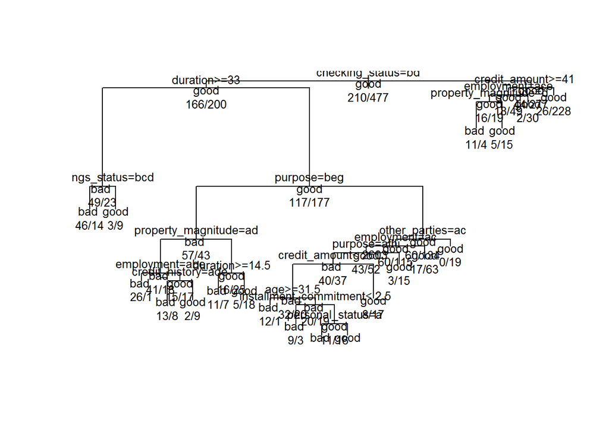

```r
plot(arvore)
text(arvore, use.n = T, all = T, cex = 0.8)
```

```r
teste <- predict(arvore, newdata = creditotest)
teste
```

```
##           bad       good
## 2   0.7666667 0.23333333
## 5   0.6111111 0.38888889
## 19  0.2125000 0.78750000
## 20  0.1023622 0.89763780
## 24  0.1666667 0.83333333
## 25  0.1023622 0.89763780
## 26  0.9230769 0.07692308
## 27  0.1023622 0.89763780
## 29  0.0000000 1.00000000
## 30  0.7666667 0.23333333
## 34  0.1023622 0.89763780
## 35  0.1023622 0.89763780
## 47  0.1023622 0.89763780
## 52  0.2125000 0.78750000
```

[output cut: 299 more lines]

```r
dim(teste)
```

```
## [1] 313   2
```

```r
dim(creditotest)
```

```
## [1] 313  21
```

```r
cred = data.frame()
cred <- cbind(creditotest, teste)
cred
```

|  | checking_status | duration | credit_history | purpose | credit_amount | savings_status | employment | installment_commitment | personal_status | other_parties | residence_since | property_magnitude | age | other_payment_plans | housing | existing_credits | job | num_dependents | own_telephone | foreign_worker | class | bad | good |
| --- | --- | --- | --- | --- | --- | --- | --- | --- | --- | --- | --- | --- | --- | --- | --- | --- | --- | --- | --- | --- | --- | --- | --- |
| 2 | 0<=X<200 | 48 | 'existing paid' | radio/tv | 5951 | <100 | 1<=X<4 | 2 | 'female div/dep/mar' | none | 2 | 'real estate' | 22 | none | own | 1 | skilled | 1 | none | yes | bad | 0.7666667 | 0.23333333 |
| 5 | <0 | 24 | 'delayed previously' | 'new car' | 4870 | <100 | 1<=X<4 | 3 | 'male single' | none | 4 | 'no known property' | 53 | none | 'for free' | 2 | skilled | 2 | none | yes | bad | 0.6111111 | 0.38888889 |
| 19 | 0<=X<200 | 24 | 'existing paid' | 'used car' | 12579 | <100 | >=7 | 4 | 'female div/dep/mar' | none | 2 | 'no known property' | 44 | none | 'for free' | 1 | 'high qualif/self emp/mgmt' | 1 | yes | yes | bad | 0.2125000 | 0.78750000 |
| 20 | 'no checking' | 24 | 'existing paid' | radio/tv | 3430 | 500<=X<1000 | >=7 | 3 | 'male single' | none | 2 | car | 31 | none | own | 1 | skilled | 2 | yes | yes | good | 0.1023622 | 0.89763780 |
| 24 | 0<=X<200 | 12 | 'critical/other existing credit' | 'used car' | 1804 | 100<=X<500 | <1 | 3 | 'male single' | none | 4 | 'life insurance' | 44 | none | own | 1 | skilled | 1 | none | yes | good | 0.1666667 | 0.83333333 |
| 25 | 'no checking' | 10 | 'critical/other existing credit' | furniture/equipment | 2069 | 'no known savings' | 1<=X<4 | 2 | 'male mar/wid' | none | 1 | car | 26 | none | own | 2 | skilled | 1 | none | no | good | 0.1023622 | 0.89763780 |
| 26 | <0 | 6 | 'existing paid' | furniture/equipment | 1374 | <100 | 1<=X<4 | 1 | 'male single' | none | 2 | 'real estate' | 36 | bank | own | 1 | 'unskilled resident' | 1 | yes | yes | good | 0.9230769 | 0.07692308 |
| 27 | 'no checking' | 6 | 'no credits/all paid' | radio/tv | 426 | <100 | >=7 | 4 | 'male mar/wid' | none | 4 | car | 39 | none | own | 1 | 'unskilled resident' | 1 | none | yes | good | 0.1023622 | 0.89763780 |
| 29 | 0<=X<200 | 7 | 'existing paid' | radio/tv | 2415 | <100 | 1<=X<4 | 3 | 'male single' | guarantor | 2 | 'real estate' | 34 | none | own | 1 | skilled | 1 | none | yes | good | 0.0000000 | 1.00000000 |
| 30 | <0 | 60 | 'delayed previously' | business | 6836 | <100 | >=7 | 3 | 'male single' | none | 4 | 'no known property' | 63 | none | own | 2 | skilled | 1 | yes | yes | bad | 0.7666667 | 0.23333333 |

[output cut: 303 more lines]

```r
cred["Result"] <- ifelse(cred$bad > 0.5, "bad", "good")
cred
```

|  | checking_status | duration | credit_history | purpose | credit_amount | savings_status | employment | installment_commitment | personal_status | other_parties | residence_since | property_magnitude | age | other_payment_plans | housing | existing_credits | job | num_dependents | own_telephone | foreign_worker | class | bad | good | Result |
| --- | --- | --- | --- | --- | --- | --- | --- | --- | --- | --- | --- | --- | --- | --- | --- | --- | --- | --- | --- | --- | --- | --- | --- | --- |
| 2 | 0<=X<200 | 48 | 'existing paid' | radio/tv | 5951 | <100 | 1<=X<4 | 2 | 'female div/dep/mar' | none | 2 | 'real estate' | 22 | none | own | 1 | skilled | 1 | none | yes | bad | 0.7666667 | 0.23333333 | bad |
| 5 | <0 | 24 | 'delayed previously' | 'new car' | 4870 | <100 | 1<=X<4 | 3 | 'male single' | none | 4 | 'no known property' | 53 | none | 'for free' | 2 | skilled | 2 | none | yes | bad | 0.6111111 | 0.38888889 | bad |
| 19 | 0<=X<200 | 24 | 'existing paid' | 'used car' | 12579 | <100 | >=7 | 4 | 'female div/dep/mar' | none | 2 | 'no known property' | 44 | none | 'for free' | 1 | 'high qualif/self emp/mgmt' | 1 | yes | yes | bad | 0.2125000 | 0.78750000 | good |
| 20 | 'no checking' | 24 | 'existing paid' | radio/tv | 3430 | 500<=X<1000 | >=7 | 3 | 'male single' | none | 2 | car | 31 | none | own | 1 | skilled | 2 | yes | yes | good | 0.1023622 | 0.89763780 | good |
| 24 | 0<=X<200 | 12 | 'critical/other existing credit' | 'used car' | 1804 | 100<=X<500 | <1 | 3 | 'male single' | none | 4 | 'life insurance' | 44 | none | own | 1 | skilled | 1 | none | yes | good | 0.1666667 | 0.83333333 | good |
| 25 | 'no checking' | 10 | 'critical/other existing credit' | furniture/equipment | 2069 | 'no known savings' | 1<=X<4 | 2 | 'male mar/wid' | none | 1 | car | 26 | none | own | 2 | skilled | 1 | none | no | good | 0.1023622 | 0.89763780 | good |
| 26 | <0 | 6 | 'existing paid' | furniture/equipment | 1374 | <100 | 1<=X<4 | 1 | 'male single' | none | 2 | 'real estate' | 36 | bank | own | 1 | 'unskilled resident' | 1 | yes | yes | good | 0.9230769 | 0.07692308 | bad |
| 27 | 'no checking' | 6 | 'no credits/all paid' | radio/tv | 426 | <100 | >=7 | 4 | 'male mar/wid' | none | 4 | car | 39 | none | own | 1 | 'unskilled resident' | 1 | none | yes | good | 0.1023622 | 0.89763780 | good |
| 29 | 0<=X<200 | 7 | 'existing paid' | radio/tv | 2415 | <100 | 1<=X<4 | 3 | 'male single' | guarantor | 2 | 'real estate' | 34 | none | own | 1 | skilled | 1 | none | yes | good | 0.0000000 | 1.00000000 | good |
| 30 | <0 | 60 | 'delayed previously' | business | 6836 | <100 | >=7 | 3 | 'male single' | none | 4 | 'no known property' | 63 | none | own | 2 | skilled | 1 | yes | yes | bad | 0.7666667 | 0.23333333 | bad |

[output cut: 303 more lines]

# Calculo de matriz de confusão

```r
confusao <- table(cred$class, cred$Result)
confusao
```

```
##
##        bad good
##   bad   36   54
##   good  45  178
```

```r
taxac <- (confusao[1] + confusao[4]) / sum(confusao)
taxac
```

```
## [1] 0.6837061
```

# Machine learning regressão

Conjunto de dados

Library para instalação de datasets: mlbench

```r
library('mlbench')
```

Dataset para regressão

```r
data("BostonHousing")
#help("BostonHousing")
```

```r
dados <- BostonHousing
dados
```

|  | crim | zn | indus | chas | nox | rm | age | dis | rad | tax | ptratio | b | lstat | medv |
| --- | --- | --- | --- | --- | --- | --- | --- | --- | --- | --- | --- | --- | --- | --- |
| 1 | 0.00632 | 18.0 | 2.31 | 0 | 0.5380 | 6.575 | 65.2 | 4.0900 | 1 | 296 | 15.3 | 396.90 | 4.98 | 24.0 |
| 2 | 0.02731 | 0.0 | 7.07 | 0 | 0.4690 | 6.421 | 78.9 | 4.9671 | 2 | 242 | 17.8 | 396.90 | 9.14 | 21.6 |
| 3 | 0.02729 | 0.0 | 7.07 | 0 | 0.4690 | 7.185 | 61.1 | 4.9671 | 2 | 242 | 17.8 | 392.83 | 4.03 | 34.7 |
| 4 | 0.03237 | 0.0 | 2.18 | 0 | 0.4580 | 6.998 | 45.8 | 6.0622 | 3 | 222 | 18.7 | 394.63 | 2.94 | 33.4 |
| 5 | 0.06905 | 0.0 | 2.18 | 0 | 0.4580 | 7.147 | 54.2 | 6.0622 | 3 | 222 | 18.7 | 396.90 | 5.33 | 36.2 |
| 6 | 0.02985 | 0.0 | 2.18 | 0 | 0.4580 | 6.430 | 58.7 | 6.0622 | 3 | 222 | 18.7 | 394.12 | 5.21 | 28.7 |
| 7 | 0.08829 | 12.5 | 7.87 | 0 | 0.5240 | 6.012 | 66.6 | 5.5605 | 5 | 311 | 15.2 | 395.60 | 12.43 | 22.9 |
| 8 | 0.14455 | 12.5 | 7.87 | 0 | 0.5240 | 6.172 | 96.1 | 5.9505 | 5 | 311 | 15.2 | 396.90 | 19.15 | 27.1 |
| 9 | 0.21124 | 12.5 | 7.87 | 0 | 0.5240 | 5.631 | 100.0 | 6.0821 | 5 | 311 | 15.2 | 386.63 | 29.93 | 16.5 |
| 10 | 0.17004 | 12.5 | 7.87 | 0 | 0.5240 | 6.004 | 85.9 | 6.5921 | 5 | 311 | 15.2 | 386.71 | 17.10 | 18.9 |

[output cut: 496 more lines]

```r
dim(dados)
```

```
## [1] 506  14
```

```r
amostra <- sample(2, 506, replace = T, prob = c(0.7, 0.3))
amostra
```

```
##   [1] 2 2 1 1 2 1 1 1 2 2 1 1 1 1 2 1 2 1 2 2 1 2 2 2 1 2 2 2 2 2 1 1 1 2 2
##  [36] 1 1 2 1 2 1 1 2 2 2 1 1 2 1 2 1 2 2 2 2 1 2 1 1 1 2 1 1 2 2 2 1 1 2 2
##  [71] 1 1 1 2 1 2 1 1 1 1 1 1 1 1 2 1 2 2 1 2 1 1 1 1 1 1 1 2 1 2 1 1 2 2 2
## [106] 1 1 1 2 1 1 2 1 1 2 1 2 1 1 2 1 2 1 1 1 1 2 2 2 1 2 2 1 1 1 1 1 1 1 2
## [141] 2 2 1 1 1 1 2 2 1 1 1 1 2 2 1 1 1 1 2 1 1 1 1 1 1 1 2 2 1 1 1 1 1 1 1
## [176] 2 1 2 1 1 1 1 2 2 1 1 2 2 2 2 2 1 2 2 1 2 1 1 1 1 1 1 1 2 2 1 1 1 1 2
## [211] 1 1 1 2 1 2 2 1 1 1 2 2 2 1 2 1 2 1 1 1 1 1 1 1 1 1 2 1 1 1 2 1 1 1 2
## [246] 1 1 2 1 1 2 1 1 2 1 2 1 1 2 2 1 1 1 1 1 2 1 1 2 1 1 2 1 1 2 1 1 1 1 2
## [281] 1 1 2 1 1 2 1 1 1 1 1 2 1 2 1 1 2 2 2 1 2 1 1 1 1 2 1 1 2 1 1 1 1 1 2
## [316] 1 2 1 2 2 2 2 1 1 1 1 1 2 1 1 1 2 2 2 1 1 2 1 2 1 1 2 1 1 2 1 2 2 2 2
## [351] 1 1 1 2 2 1 1 2 1 2 2 1 2 1 2 1 1 2 1 1 2 2 2 1 1 1 1 1 2 1 1 1 2 2 2
## [386] 1 2 1 2 1 1 1 1 1 1 1 2 2 2 1 2 1 2 2 1 2 2 2 1 1 1 1 1 1 1 2 2 1 2 1
## [421] 1 1 1 1 1 1 1 1 2 1 2 1 1 1 1 2 1 1 1 2 1 2 1 2 1 1 1 1 2 2 1 1 1 2 1
## [456] 1 1 2 1 1 2 2 1 1 1 2 2 1 1 2 1 1 2 2 1 2 2 1 1 2 1 2 1 1 1 1 1 2 1 1
## [491] 2 2 2 1 2 2 1 1 2 1 1 1 1 1 1 1
```

```r
dadostreino <- dados[amostra == 1,]
dadosteste <-  dados[amostra == 2,]

print(dim(dadostreino))
```

```
## [1] 315  14
```

```r
print(dim(dadosteste))
```

```
## [1] 191  14
```

```r
head(dados$medv, 10)
```

```
##  [1] 24.0 21.6 34.7 33.4 36.2 28.7 22.9 27.1 16.5 18.9
```

```r
fit <- rpart(medv ~., data = dadostreino, method = "anova")
fit
```

```
## n= 315
##
## node), split, n, deviance, yval
##       * denotes terminal node
##
##  1) root 315 25726.9700 22.43238
##    2) rm< 6.853 263  9589.6790 19.68479
##      4) lstat>=14.4 115  2277.6360 15.37826
##        8) nox>=0.607 68   831.3887 13.15441
##         16) crim>=9.160925 31   214.3200 10.70000 *
##         17) crim< 9.160925 37   273.8557 15.21081 *
##        9) nox< 0.607 47   623.3991 18.59574 *
##      5) lstat< 14.4 148  3521.9770 23.03108
##       10) lstat>=4.695 140  1658.7430 22.34286
##         20) rm< 6.079 54   396.6000 20.20000 *
##         21) rm>=6.079 86   858.4884 23.68837 *
##       11) lstat< 4.695 8   636.4750 35.07500 *
##    3) rm>=6.853 52  4110.0270 36.32885
##      6) rm< 7.437 34  1172.1010 31.17647
##       12) ptratio>=18.55 7   406.2486 23.68571 *
##       13) ptratio< 18.55 27   271.2407 33.11852 *
##      7) rm>=7.437 18   330.4228 46.06111 *
```

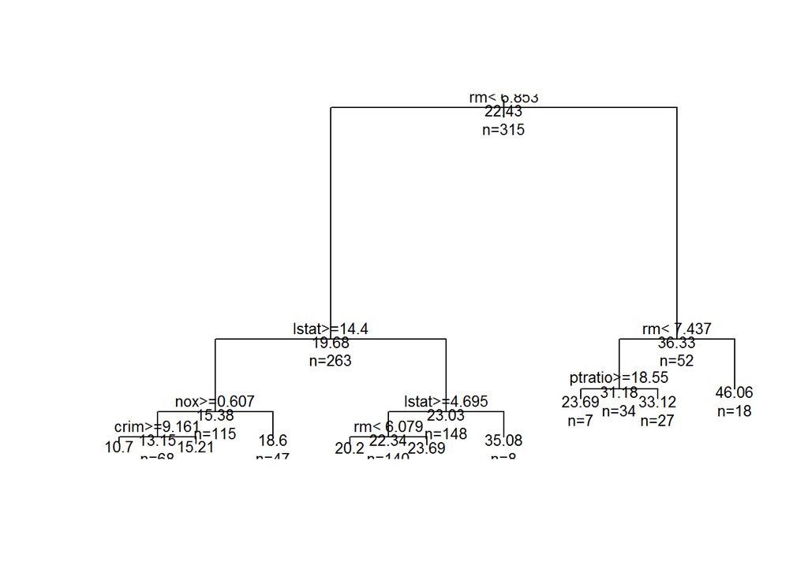

```r
plot(fit)
text(fit, use.n = T, all = T, cex = 0.8)
```

```r
prev <- predict(fit, newdata = dadosteste)
prev
```

```
##        1        2        5        9       10       15       17       19
## 23.68837 23.68837 23.68571 18.59574 18.59574 23.68837 20.20000 20.20000
##       20       22       23       24       26       27       28       29
## 20.20000 20.20000 18.59574 18.59574 18.59574 18.59574 18.59574 23.68837
##       30       34       35       38       40       43       44       45
## 23.68837 18.59574 18.59574 20.20000 35.07500 23.68837 23.68837 20.20000
##       48       50       52       53       54       55       57       61
## 18.59574 18.59574 23.68837 23.68837 20.20000 18.59574 23.68837 20.20000
##       64       65       66       69       70       74       76       85
## 23.68837 23.68571 35.07500 20.20000 20.20000 23.68837 23.68837 23.68837
##       87       88       90       98      100      103      104      105
## 20.20000 23.68837 33.11852 46.06111 33.11852 23.68837 23.68837 23.68837
##      109      112      115      117      120      122      127      128
## 23.68837 23.68837 23.68837 23.68837 20.20000 20.20000 18.59574 15.21081
##      129      131      132      140      141      142      147      148
## 15.21081 23.68837 23.68837 15.21081 15.21081 15.21081 15.21081 15.21081
##      153      154      159      167      168      176      178      183
## 20.20000 15.21081 20.20000 46.06111 20.20000 23.68837 23.68837 33.11852
##      184      187      188      189      190      191      193      194
## 23.68837 46.06111 23.68837 35.07500 33.11852 33.11852 33.11852 23.68837
##      196      204      205      210      214      216      217      221
## 46.06111 46.06111 46.06111 18.59574 23.68837 23.68837 20.20000 33.11852
##      222      223      225      227      237      241      245      248
## 18.59574 33.11852 46.06111 46.06111 23.68837 33.11852 20.20000 23.68837
##      251      254      256      259      260      266      269      272
## 23.68837 46.06111 20.20000 33.11852 23.68837 20.20000 46.06111 23.68837
##      275      280      283      286      292      294      297      298
## 35.07500 23.68837 46.06111 23.68837 23.68571 23.68837 23.68837 18.59574
##      299      301      306      309      315      317      319      320
## 23.68837 33.11852 23.68837 35.07500 23.68837 18.59574 23.68837 23.68837
##      321      322      328      332      333      334      337      339
## 23.68837 23.68837 23.68837 20.20000 20.20000 23.68837 20.20000 20.20000
##      342      345      347      348      349      350      354      355
## 33.11852 33.11852 20.20000 23.68837 23.68837 23.68571 35.07500 20.20000
##      358      360      361      363      365      368      371      372
## 23.68837 23.68837 23.68837 20.20000 46.06111 20.20000 23.68571 23.68837
##      373      379      383      384      385      387      389      397
## 20.20000 10.70000 10.70000 15.21081 10.70000 10.70000 10.70000 15.21081
##      398      399      401      403      404      406      407      408
## 15.21081 10.70000 10.70000 10.70000 10.70000 10.70000 10.70000 20.20000
##      416      417      419      429      431      436      440      442
## 10.70000 10.70000 10.70000 15.21081 18.59574 10.70000 10.70000 10.70000
##      444      449      450      454      458      461      462      466
## 10.70000 10.70000 15.21081 23.68571 15.21081 15.21081 15.21081 20.20000
##      467      470      473      474      476      477      480      482
## 15.21081 18.59574 23.68837 23.68571 18.59574 15.21081 23.68837 23.68837
##      488      491      492      493      495      496      499
## 20.20000 15.21081 15.21081 20.20000 20.20000 18.59574 20.20000
```

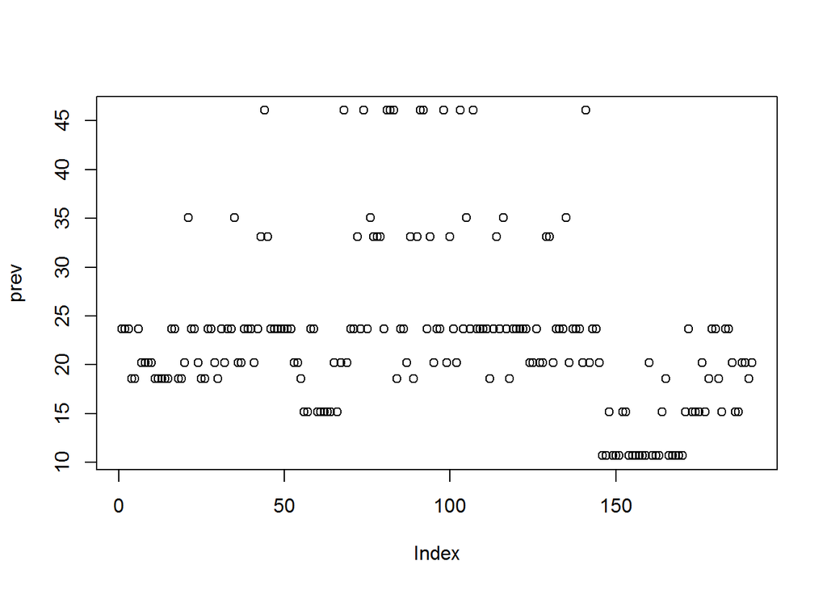

```r
plot(prev)
```

```r
summary(prev)
```

```
##    Min. 1st Qu.  Median    Mean 3rd Qu.    Max.
##   10.70   18.60   23.69   22.71   23.69   46.06
```

```r
r <- cbind(dadosteste, prev)
r
```

|  | crim | zn | indus | chas | nox | rm | age | dis | rad | tax | ptratio | b | lstat | medv | prev |
| --- | --- | --- | --- | --- | --- | --- | --- | --- | --- | --- | --- | --- | --- | --- | --- |
| 1 | 0.00632 | 18.0 | 2.31 | 0 | 0.5380 | 6.575 | 65.2 | 4.0900 | 1 | 296 | 15.3 | 396.90 | 4.98 | 24.0 | 23.68837 |
| 2 | 0.02731 | 0.0 | 7.07 | 0 | 0.4690 | 6.421 | 78.9 | 4.9671 | 2 | 242 | 17.8 | 396.90 | 9.14 | 21.6 | 23.68837 |
| 5 | 0.06905 | 0.0 | 2.18 | 0 | 0.4580 | 7.147 | 54.2 | 6.0622 | 3 | 222 | 18.7 | 396.90 | 5.33 | 36.2 | 23.68571 |
| 9 | 0.21124 | 12.5 | 7.87 | 0 | 0.5240 | 5.631 | 100.0 | 6.0821 | 5 | 311 | 15.2 | 386.63 | 29.93 | 16.5 | 18.59574 |
| 10 | 0.17004 | 12.5 | 7.87 | 0 | 0.5240 | 6.004 | 85.9 | 6.5921 | 5 | 311 | 15.2 | 386.71 | 17.10 | 18.9 | 18.59574 |
| 15 | 0.63796 | 0.0 | 8.14 | 0 | 0.5380 | 6.096 | 84.5 | 4.4619 | 4 | 307 | 21.0 | 380.02 | 10.26 | 18.2 | 23.68837 |
| 17 | 1.05393 | 0.0 | 8.14 | 0 | 0.5380 | 5.935 | 29.3 | 4.4986 | 4 | 307 | 21.0 | 386.85 | 6.58 | 23.1 | 20.20000 |
| 19 | 0.80271 | 0.0 | 8.14 | 0 | 0.5380 | 5.456 | 36.6 | 3.7965 | 4 | 307 | 21.0 | 288.99 | 11.69 | 20.2 | 20.20000 |
| 20 | 0.72580 | 0.0 | 8.14 | 0 | 0.5380 | 5.727 | 69.5 | 3.7965 | 4 | 307 | 21.0 | 390.95 | 11.28 | 18.2 | 20.20000 |
| 22 | 0.85204 | 0.0 | 8.14 | 0 | 0.5380 | 5.965 | 89.2 | 4.0123 | 4 | 307 | 21.0 | 392.53 | 13.83 | 19.6 | 20.20000 |

[output cut: 181 more lines]

```r
r$dif <- abs(r$medv - r$prev)
r
```

|  | crim | zn | indus | chas | nox | rm | age | dis | rad | tax | ptratio | b | lstat | medv | prev | dif |
| --- | --- | --- | --- | --- | --- | --- | --- | --- | --- | --- | --- | --- | --- | --- | --- | --- |
| 1 | 0.00632 | 18.0 | 2.31 | 0 | 0.5380 | 6.575 | 65.2 | 4.0900 | 1 | 296 | 15.3 | 396.90 | 4.98 | 24.0 | 23.68837 | 0.31162791 |
| 2 | 0.02731 | 0.0 | 7.07 | 0 | 0.4690 | 6.421 | 78.9 | 4.9671 | 2 | 242 | 17.8 | 396.90 | 9.14 | 21.6 | 23.68837 | 2.08837209 |
| 5 | 0.06905 | 0.0 | 2.18 | 0 | 0.4580 | 7.147 | 54.2 | 6.0622 | 3 | 222 | 18.7 | 396.90 | 5.33 | 36.2 | 23.68571 | 12.51428571 |
| 9 | 0.21124 | 12.5 | 7.87 | 0 | 0.5240 | 5.631 | 100.0 | 6.0821 | 5 | 311 | 15.2 | 386.63 | 29.93 | 16.5 | 18.59574 | 2.09574468 |
| 10 | 0.17004 | 12.5 | 7.87 | 0 | 0.5240 | 6.004 | 85.9 | 6.5921 | 5 | 311 | 15.2 | 386.71 | 17.10 | 18.9 | 18.59574 | 0.30425532 |
| 15 | 0.63796 | 0.0 | 8.14 | 0 | 0.5380 | 6.096 | 84.5 | 4.4619 | 4 | 307 | 21.0 | 380.02 | 10.26 | 18.2 | 23.68837 | 5.48837209 |
| 17 | 1.05393 | 0.0 | 8.14 | 0 | 0.5380 | 5.935 | 29.3 | 4.4986 | 4 | 307 | 21.0 | 386.85 | 6.58 | 23.1 | 20.20000 | 2.90000000 |
| 19 | 0.80271 | 0.0 | 8.14 | 0 | 0.5380 | 5.456 | 36.6 | 3.7965 | 4 | 307 | 21.0 | 288.99 | 11.69 | 20.2 | 20.20000 | 0.00000000 |
| 20 | 0.72580 | 0.0 | 8.14 | 0 | 0.5380 | 5.727 | 69.5 | 3.7965 | 4 | 307 | 21.0 | 390.95 | 11.28 | 18.2 | 20.20000 | 2.00000000 |
| 22 | 0.85204 | 0.0 | 8.14 | 0 | 0.5380 | 5.965 | 89.2 | 4.0123 | 4 | 307 | 21.0 | 392.53 | 13.83 | 19.6 | 20.20000 | 0.60000000 |

[output cut: 181 more lines]

```r
max(r$dif)
```

```
## [1] 29.8
```

```r
min(r$dif)
```

```
## [1] 0
```

```r
mean(r$dif)
```

```
## [1] 3.559891
```

```r
media <- mean(r$dif) * 1.3
media
```

```
## [1] 4.627859
```

Calcular o percentual de erro

```r
proc <- (sum(r$dif <= media) * 100) / dim(r)[1]
proc
```

```
## [1] 76.96335
```

# Seleção de atributos

Serve para criar modelos mais simples

Biblioteca e1071

```r
library(e1071)
credito
```

| checking_status | duration | credit_history | purpose | credit_amount | savings_status | employment | installment_commitment | personal_status | other_parties | residence_since | property_magnitude | age | other_payment_plans | housing | existing_credits | job | num_dependents | own_telephone | foreign_worker | class |
| --- | --- | --- | --- | --- | --- | --- | --- | --- | --- | --- | --- | --- | --- | --- | --- | --- | --- | --- | --- | --- |
| <0 | 6 | 'critical/other existing credit' | radio/tv | 1169 | 'no known savings' | >=7 | 4 | 'male single' | none | 4 | 'real estate' | 67 | none | own | 2 | skilled | 1 | yes | yes | good |
| 0<=X<200 | 48 | 'existing paid' | radio/tv | 5951 | <100 | 1<=X<4 | 2 | 'female div/dep/mar' | none | 2 | 'real estate' | 22 | none | own | 1 | skilled | 1 | none | yes | bad |
| 'no checking' | 12 | 'critical/other existing credit' | education | 2096 | <100 | 4<=X<7 | 2 | 'male single' | none | 3 | 'real estate' | 49 | none | own | 1 | 'unskilled resident' | 2 | none | yes | good |
| <0 | 42 | 'existing paid' | furniture/equipment | 7882 | <100 | 4<=X<7 | 2 | 'male single' | guarantor | 4 | 'life insurance' | 45 | none | 'for free' | 1 | skilled | 2 | none | yes | good |
| <0 | 24 | 'delayed previously' | 'new car' | 4870 | <100 | 1<=X<4 | 3 | 'male single' | none | 4 | 'no known property' | 53 | none | 'for free' | 2 | skilled | 2 | none | yes | bad |
| 'no checking' | 36 | 'existing paid' | education | 9055 | 'no known savings' | 1<=X<4 | 2 | 'male single' | none | 4 | 'no known property' | 35 | none | 'for free' | 1 | 'unskilled resident' | 2 | yes | yes | good |
| 'no checking' | 24 | 'existing paid' | furniture/equipment | 2835 | 500<=X<1000 | >=7 | 3 | 'male single' | none | 4 | 'life insurance' | 53 | none | own | 1 | skilled | 1 | none | yes | good |
| 0<=X<200 | 36 | 'existing paid' | 'used car' | 6948 | <100 | 1<=X<4 | 2 | 'male single' | none | 2 | car | 35 | none | rent | 1 | 'high qualif/self emp/mgmt' | 1 | yes | yes | good |
| 'no checking' | 12 | 'existing paid' | radio/tv | 3059 | >=1000 | 4<=X<7 | 2 | 'male div/sep' | none | 4 | 'real estate' | 61 | none | own | 1 | 'unskilled resident' | 1 | none | yes | good |
| 0<=X<200 | 30 | 'critical/other existing credit' | 'new car' | 5234 | <100 | unemployed | 4 | 'male mar/wid' | none | 2 | car | 28 | none | own | 2 | 'high qualif/self emp/mgmt' | 1 | none | yes | bad |

[output cut: 990 more lines]

```r
modelo <- svm(class ~., creditotreino)
modelo
```

```
##
## Call:
## svm(formula = class ~ ., data = creditotreino)
##
##
## Parameters:
##    SVM-Type:  C-classification
##  SVM-Kernel:  radial
##        cost:  1
##       gamma:  0.02040816
##
## Number of Support Vectors:  429
```

```r
pred <- predict(modelo, creditotest)
pred
```

```
##    2    5   19   20   24   25   26   27   29   30   34   35   47   52   58
## good  bad  bad good good good good good good  bad good good good good good
##   59   63   65   66   69   71   74   75   76   85   91   93   99  103  105
## good good good good good good good good good good good good good good good
##  108  111  114  115  118  119  120  127  141  143  146  154  155  161  167
## good good  bad good good good good good good  bad good good good good  bad
##  168  170  172  178  180  182  188  189  191  192  193  195  197  202  204
## good good good good good good good good good good good good good  bad  bad
##  206  209  210  216  217  220  221  225  228  234  235  236  240  244  246
##  bad  bad good good good good good good good good good  bad good good good
##  251  257  258  259  261  263  271  273  276  280  283  284  285  287  289
## good good good good good good good  bad good good good good good  bad good
##  291  297  299  301  302  303  310  311  312  320  326  329  333  335  336
## good good good good good good good good good good good good  bad  bad good
##  339  342  348  350  354  355  364  368  372  375  380  382  384  391  393
##  bad good good good  bad good good  bad good  bad good  bad good good  bad
##  398  400  404  408  412  415  416  417  426  427  430  431  435  436  439
## good good good good good  bad good  bad good good good good good good  bad
##  440  445  447  448  451  452  453  455  457  461  465  467  473  474  480
## good good  bad good good good good good good good good  bad  bad good good
##  482  484  495  496  497  500  503  507  508  510  511  513  514  515  518
## good good good good  bad good good good good good good good good good good
##  519  521  522  528  531  532  537  539  545  548  554  555  557  559  562
## good good good good  bad good good  bad good good good good good good  bad
##  565  569  571  573  576  578  579  587  589  590  591  593  598  600  602
## good good  bad good good good  bad good good good good good good good good
##  603  609  611  612  613  615  621  623  624  626  627  628  631  636  648
## good good good good good good good good  bad good good good good good good
##  651  661  665  675  680  685  686  687  691  692  693  697  700  710  712
##  bad good good good good good good good good good good good good good good
##  713  718  719  723  724  728  738  744  747  752  755  758  761  762  765
## good good good  bad good  bad good good  bad good good good good good good
##  766  767  769  770  771  776  777  778  779  781  782  786  789  794  795
## good good good good good  bad good good good good good good  bad good good
##  796  797  798  801  804  806  808  812  818  819  821  826  831  834  835
## good good good good good  bad good good good  bad good  bad good good good
##  837  839  845  850  867  869  871  875  877  880  884  885  890  894  898
## good good good good  bad good good good good good good good good good good
##  904  906  917  919  921  925  926  929  931  933  935  936  943  951  952
## good good good good good good  bad good good good  bad good good good good
##  953  955  957  964  969  970  972  975  985  992  993  998  999
## good good good good good good good good good good good good  bad
## Levels: bad good
```

```r
confusao <- table(creditotest$class,pred)
confusao
```

```
##       pred
##        bad good
##   bad   29   61
##   good  18  205
```

taxa de acerto

```r
taxac1 <- (confusao[1] + confusao[4]) / sum(confusao)
taxac1 * 100
```

```
## [1] 74.76038
```

Seleção de atributos pega os atributos mais importantes em relação ao modelo

pacote FSelector

```r
library(FSelector)
seletores <- random.forest.importance(class ~., credito)
seletores
```

|  | attr_importance |
| --- | --- |
| checking_status | 49.631445 |
| duration | 29.825444 |
| credit_history | 22.057463 |
| purpose | 11.357038 |
| credit_amount | 18.587725 |
| savings_status | 12.839347 |
| employment | 7.517033 |
| installment_commitment | 6.323601 |
| personal_status | 4.177567 |
| other_parties | 12.110980 |

[output cut: 10 more lines]

```r
modelo2 <- svm(class ~ checking_status + duration + credit_history + purpose, creditotreino)
modelo2
```

```
##
## Call:
## svm(formula = class ~ checking_status + duration + credit_history +
##     purpose, data = creditotreino)
##
##
## Parameters:
##    SVM-Type:  C-classification
##  SVM-Kernel:  radial
##        cost:  1
##       gamma:  0.05555556
##
## Number of Support Vectors:  412
```

```r
pred2 <- predict(modelo2, creditotest)
pred2
```

```
##    2    5   19   20   24   25   26   27   29   30   34   35   47   52   58
## good  bad good good good good good good good  bad good good good good good
##   59   63   65   66   69   71   74   75   76   85   91   93   99  103  105
## good good good good good good good  bad good good good good good good good
##  108  111  114  115  118  119  120  127  141  143  146  154  155  161  167
## good good good good good good good good good  bad  bad good good good good
##  168  170  172  178  180  182  188  189  191  192  193  195  197  202  204
## good good good good good good good good good  bad good good good good good
##  206  209  210  216  217  220  221  225  228  234  235  236  240  244  246
## good good good good  bad good good good good good good  bad  bad good good
##  251  257  258  259  261  263  271  273  276  280  283  284  285  287  289
## good good good good good good good  bad good good good good good  bad good
##  291  297  299  301  302  303  310  311  312  320  326  329  333  335  336
## good good good good good good good  bad good good good good  bad  bad good
##  339  342  348  350  354  355  364  368  372  375  380  382  384  391  393
## good good good good  bad good good good good  bad good good good good  bad
##  398  400  404  408  412  415  416  417  426  427  430  431  435  436  439
##  bad good good good good  bad good good good good good good good good  bad
##  440  445  447  448  451  452  453  455  457  461  465  467  473  474  480
## good good  bad good good good good  bad good  bad good good good good good
##  482  484  495  496  497  500  503  507  508  510  511  513  514  515  518
## good good good good good good good good good good good good good good good
##  519  521  522  528  531  532  537  539  545  548  554  555  557  559  562
## good good good good good good good  bad good good good good good  bad  bad
##  565  569  571  573  576  578  579  587  589  590  591  593  598  600  602
## good good good good good good good good good good good good good good good
##  603  609  611  612  613  615  621  623  624  626  627  628  631  636  648
## good good good good good good good good good good good good  bad good good
##  651  661  665  675  680  685  686  687  691  692  693  697  700  710  712
##  bad good good good good good good good good good good good good good good
##  713  718  719  723  724  728  738  744  747  752  755  758  761  762  765
## good good good good good good  bad  bad good  bad good good good good good
##  766  767  769  770  771  776  777  778  779  781  782  786  789  794  795
## good  bad good good good  bad good good good good good good good good good
##  796  797  798  801  804  806  808  812  818  819  821  826  831  834  835
## good good good good good  bad good good good  bad good good good good good
##  837  839  845  850  867  869  871  875  877  880  884  885  890  894  898
## good good good good good good good good good good good good good good good
##  904  906  917  919  921  925  926  929  931  933  935  936  943  951  952
## good good good good good  bad good good good good good good good good  bad
##  953  955  957  964  969  970  972  975  985  992  993  998  999
## good good good good good good good good good good good good  bad
## Levels: bad good
```

```r
confusao2 <- table(creditotest$class,pred2)
confusao2
```

```
##       pred2
##        bad good
##   bad   22   68
##   good  16  207
```

```r
taxac2 <- (confusao2[1] + confusao2[4]) / sum(confusao2)
taxac2 * 100
```

```
## [1] 73.16294
```

```r
print(taxac1 * 100)
```

```
## [1] 74.76038
```

```r
print(taxac2 * 100)
```

```
## [1] 73.16294
```

# KNN

Aprendizado baseado em instância, não cria um modelo

pacotes: class

```r
library(class)
```

## criação de amostra

Neste tipo de treinamento criamos duas amostras

```r
amostra <- sample(2, 150, replace = T, prob = c(0.7,0.3))
iristreino <- iris[amostra == 1,]
classificar <- iris[amostra == 2,]
```

```r
dim(iristreino)
```

```
## [1] 96  5
```

```r
dim(classificar)
```

```
## [1] 54  5
```

```r
head(iristreino)
```

|  | Sepal.Length | Sepal.Width | Petal.Length | Petal.Width | Species |
| --- | --- | --- | --- | --- | --- |
| 1 | 5.1 | 3.5 | 1.4 | 0.2 | setosa |
| 3 | 4.7 | 3.2 | 1.3 | 0.2 | setosa |
| 4 | 4.6 | 3.1 | 1.5 | 0.2 | setosa |
| 5 | 5.0 | 3.6 | 1.4 | 0.2 | setosa |
| 6 | 5.4 | 3.9 | 1.7 | 0.4 | setosa |
| 7 | 4.6 | 3.4 | 1.4 | 0.3 | setosa |

```r
levels(iris$Species)
```

```
## [1] "setosa"     "versicolor" "virginica"
```

```r
previsao <- knn(iristreino[,1:4], classificar[, 1:4], iristreino[,5], k = 3)
previsao
```

```
##  [1] setosa     setosa     setosa     setosa     setosa     setosa
##  [7] setosa     setosa     setosa     setosa     setosa     setosa
## [13] versicolor versicolor versicolor versicolor versicolor versicolor
## [19] virginica  versicolor versicolor versicolor versicolor versicolor
## [25] versicolor versicolor versicolor versicolor versicolor versicolor
## [31] versicolor versicolor virginica  virginica  virginica  virginica
## [37] virginica  virginica  virginica  virginica  virginica  virginica
## [43] virginica  virginica  virginica  virginica  virginica  virginica
## [49] virginica  virginica  virginica  virginica  virginica  virginica
## Levels: setosa versicolor virginica
```

```r
confusao <- table(classificar[,5], previsao)
confusao
```

```
##             previsao
##              setosa versicolor virginica
##   setosa         12          0         0
##   versicolor      0         19         1
##   virginica       0          0        22
```

```r
taxac <- (confusao[1] + confusao[5] + confusao[9]) / sum(confusao)
taxac * 100
```

```
## [1] 98.14815
```